# Predicting heights - WEEK 4 PGA

Prediction of child heights using linear modelling

Nikhil

25/11/2021

# Aim of the assignment

Firstly, We must create a Shiny application the takes in user data, performs calculation on that input and provides the output. Thsi must be a dynamic input meaning it mus change if the user input changes any number of times. Second, we have to create an slidify presentation which shows what the application does.

# Usage of the application

The app basically provides to predict the child’s hight, based on their gender and the height of their parents using linear regression

To use the app, simply use the slider on the left hand side of the page to chose the heights of parents and use the radio buttons to choose the gender of the expected/born child. The app will then predict the height using these factor using linear regression and give the result in a textual as well as graph format. The maximum and minimum value of the parents’ heights are chosen as per the dataset.

# Plot

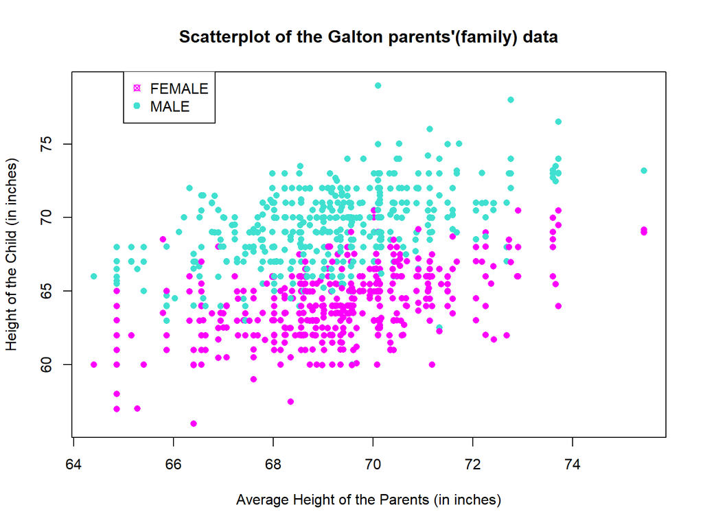

```r
library(HistData)

data(GaltonFamilies)
library(HistData)
data(GaltonFamilies)
plot(jitter(GaltonFamilies$childHeight) ~ GaltonFamilies$midparentHeight,xlab="Average Height of the Parents (in inches)",ylab="Height of the Child (in inches)",main="Scatterplot of the Galton parents'(family) data",pch=16,frame.plot=TRUE,col=ifelse(GaltonFamilies$gender=="female", "magenta", "turquoise"))
legend(65,80,pch=c(13,19),col=c("magenta","turquoise"),c("FEMALE", "MALE"),bty="o")
```

# Thank You

This app was made for educational purposes and i thank you for your time to test it out. This can be further extended to go for Galton’s original aim, to test associative partner selection, at a later stage.